# Regression Analysis of the “mtcars” Dataset

Vasilena Taralova

# 1 Executive Summary

In this report we investigate the relationship between miles per gallon (MPG) and a set of variables based on the data set “mtcars” available in the R “datasets” package. We are particularly interested in the effect of transimission type (coded as “am”) on miles per gallon (coded as “mpg”). We perform a detailed statistical analysis and we fit two linear regression models. The first model is a simple linear regression with the “mpg” as the response variable and the type of transmission as the predictor. Our analysis shows that “am” affects “mpg” when other factors are not included. More precisely, cars with manual transimission have greater “mpg” than cars with automatic transmission. On the other hand, when the number of cylinders and the weight of the vehicle are also taken into account (i.e. included as predictors in the regression model), we found that the type of transmission does not have an impact on the miles per gallon. In the multivariable regression model the miles per gallon decrease when the number of cylinders increases or the car gets heavier.

# 2 Exploratory Data Analysis

First we load the packages that we will need - “ggplot2”, “lmtest”, “knitr” and “gridExtra”:

```r
library(ggplot2)
library(lmtest)
library(knitr)
library(gridExtra)
```

Then we load the “mtcars” data frame and investigate its structure:

```r
data("mtcars")

str(mtcars)
```

```
'data.frame':   32 obs. of  11 variables:
 $ mpg : num  21 21 22.8 21.4 18.7 18.1 14.3 24.4 22.8 19.2 ...
 $ cyl : num  6 6 4 6 8 6 8 4 4 6 ...
 $ disp: num  160 160 108 258 360 ...
 $ hp  : num  110 110 93 110 175 105 245 62 95 123 ...
 $ drat: num  3.9 3.9 3.85 3.08 3.15 2.76 3.21 3.69 3.92 3.92 ...
 $ wt  : num  2.62 2.88 2.32 3.21 3.44 ...
 $ qsec: num  16.5 17 18.6 19.4 17 ...
 $ vs  : num  0 0 1 1 0 1 0 1 1 1 ...
 $ am  : num  1 1 1 0 0 0 0 0 0 0 ...
 $ gear: num  4 4 4 3 3 3 3 4 4 4 ...
 $ carb: num  4 4 1 1 2 1 4 2 2 4 ...
```

Since the variable “am” is coded as numeric we have to transform it into a factor variable. We code the factor levels as “Automatic” and “Manual”.

```r
mtcars$am <- factor(mtcars$am, labels = c("Automatic", "Manual"))
```

Below we give summary statistics about miles per gallon grouped by transmission type:

```r
summary.auto <- summary(subset(mtcars$mpg, mtcars$am == "Automatic"))
summary.manual <- summary(subset(mtcars$mpg, mtcars$am == "Manual"))

mat <- matrix(c(summary.auto, summary.manual), nrow = 2, byrow = TRUE,
              dimnames = list(c("Auto", "Manual"),
                              c("Min", "1st Qu.", "Median", "Mean", "3rd Qu.", "Max")))

kable(mat)
```

|  | Min | 1st Qu. | Median | Mean | 3rd Qu. | Max |
| --- | --- | --- | --- | --- | --- | --- |
| Auto | 10.4 | 14.95 | 17.3 | 17.15 | 19.2 | 24.4 |
| Manual | 15.0 | 21.00 | 22.8 | 24.39 | 30.4 | 33.9 |

As we can see from the table above and the box plot below, both the median and mean of the manual transmission are considerably bigger than those of the automatic transmission.

```r
g1 <- ggplot(data = mtcars, aes(x = factor(0), y = mpg)) +
        geom_boxplot() +
        stat_summary(fun.y = mean,
                     geom = 'point',
                     shape = 16,
                     col = "red",
                     cex = 2) +
        ylab("Mpg") +
        xlab("") +
        scale_x_discrete(breaks = NULL) +
        ggtitle("Box plot of mpg by transmission type") +
        facet_wrap(~am) +
        theme(plot.title = element_text(size = 10, face = "bold"))
```

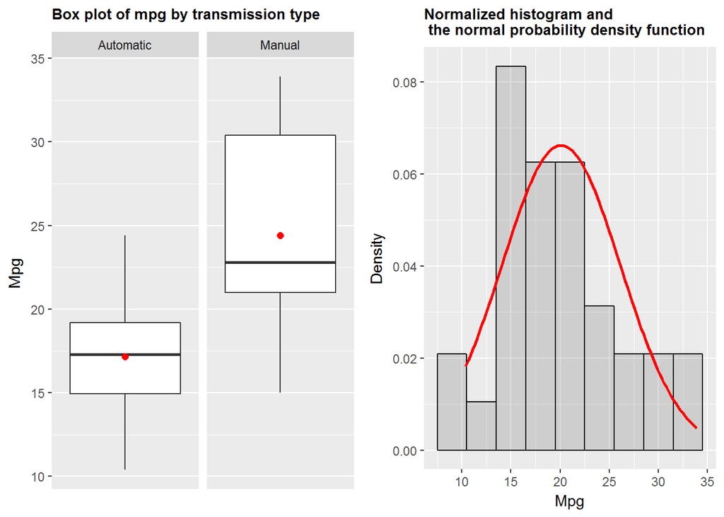

```r
g2 <- ggplot(data = mtcars, aes(x = mpg)) +
        geom_histogram(aes(y = ..density..),
                       binwidth = 3,
                       colour = "black",
                       alpha = 0.2) +
        stat_function(fun = dnorm,
                       args = list(mean = mean(mtcars$mpg),
                                   sd = sd(mtcars$mpg)),
                       lwd = 1,
                       col = "red") +
        scale_x_continuous(breaks = seq(0, 50, 5)) +
        labs(x = "Mpg",
             y = "Density") +
        ggtitle("Normalized histogram and \n the normal probability density function") +
        theme(plot.title = element_text(size = 10, face = "bold"))

grid.arrange(grobs = list(g1,g2), ncol = 2)
```

The “mpg” data points are approximately normally distributed as we can see from the histogram of “mpg” above. This is one of the main assumptions of the linear regression.

# 3 Confidence Intervals and Hypothesis Testing

We test the null hypothesis (at the 5% significance level) that the difference between the population mean of mpg for cars with manual transmission is equal to that of cars with automatic transmission. The alternative hypothesis is that the difference in mpg for automatic and manual transmission is not equal to zero.

```r
mpg.auto <- subset(mtcars, mtcars$am == "Automatic")$mpg
mpg.manual <- subset(mtcars, mtcars$am == "Manual")$mpg

test <- t.test(x = mpg.auto,
               y = mpg.manual,
               alternative = "two.sided",
               mu = 0,
               paired = FALSE,
               var.equal = FALSE,
               conf.level = 0.95)

test
```

```
    Welch Two Sample t-test

data:  mpg.auto and mpg.manual
t = -3.7671, df = 18.332, p-value = 0.001374
alternative hypothesis: true difference in means is not equal to 0
95 percent confidence interval:
 -11.280194  -3.209684
sample estimates:
mean of x mean of y
 17.14737  24.39231
```

The corresponding 95% t-confidence interval (we assume the data is normally distributed) is given separately below:

```r
int.df <- data.frame(test$conf.int[1], test$conf.int[2])

colnames(int.df) <- c("Lower Bound", "Upper Bound")

kable(int.df)
```

| Lower Bound | Upper Bound |
| --- | --- |
| -11.28019 | -3.209684 |

The resulting p-value is equal to 0.0014 and is less than 0.05 which means that we reject the null hypothesis in favour of the alternative hypothesis.

# 4 Simple Linear Regression

We fit a simple linear regression model with “mpg” as the outcome (response variable) and “am” as the predictor. We assume that the values of “mpg” are normally distributed and as we can see from the histogram of “mpg”, this is approximately the case. Since “am” is a factor variable, R automatically transforms “am” into a dummy variable and chooses as a reference level “automatic”, which is the first level alphabetically. This means that the automatic transmission is coded as 0 and the manual transmission is coded as 1.

```r
LinMod <- lm(mpg ~ am, data = mtcars)
```

Below we show a table with summary statistics about the model coefficients in the simple linear regression model:

```r
summary.df <- data.frame(summary(LinMod)$coefficients)

colnames(summary.df) <- c("Estimate", "Std.Error", "t.value", "P.Value")

kable(summary.df)
```

|  | Estimate | Std.Error | t.value | P.Value |
| --- | --- | --- | --- | --- |
| (Intercept) | 17.147368 | 1.124602 | 15.247492 | 0.000000 |
| amManual | 7.244939 | 1.764422 | 4.106127 | 0.000285 |

The intercept (17.147) is the estimated expected “mpg” for automatic transmission, whereas the slope (7.245), is the estimated expected difference between “mpg” for manual transmission and “mpg” for automatic transmission. This means that “mpg” is bigger for manual transmission than for automatic and the estimated expected mean of this difference is about $7.24$ miles per gallon.

```r
summary(LinMod)$adj.r.squared
```

```
## [1] 0.3384589
```

We observe that the adjusted R squared (which accounts for the effect of including more variables) is 0.338, which means that the fitted model explains only about 33.8% of the variance in “mpg”. We can make and the following interesting observation. Since the only predictor in the linear model is the factor variable “am” (transmission type), it can be shown that the intercept, which is the estimated expected “mpg” for automatic transmission, is equal to the observed mean “mpg” for automatic transmission. Furthermore, the slope, which is the estimated expected difference between “mpg” for manual transmission and “mpg” for automatic transmission, is equal to the empirical mean “mpg” for manual transmission minus the empirical mean “mpg” for automatic transmission. Below we show the respective empirical mean “mpg” for automatic and manual transmission and we see that, indeed, the intercept coincides with the observed mean “mpg” for automatic transmission, and the difference between the observed mean “mpg” for manual and automatic transmission is equal to the slope:

```r
mean.auto <- mean(subset(mtcars, mtcars$am == "Automatic")$mpg)
mean.manual <- mean(subset(mtcars, mtcars$am == "Manual")$mpg)

mean.df <- data.frame(mean.auto, mean.manual, mean.manual - mean.auto)

colnames(mean.df) <- c("Mean MPG for Automatic", "Mean MPG for Manual", "Difference")

kable(mean.df)
```

| Mean MPG for Automatic | Mean MPG for Manual | Difference |
| --- | --- | --- |
| 17.14737 | 24.39231 | 7.244939 |

This means that the predicted “mpg” for automatic transmission will be equal to the empirical mean “mpg” for automatic transmission for all cars and the predicted “mpg” for manual transmission will be equal to the empirical mean “mpg” for manual transmission for all cars. Hence, the predicted “mpg” is just the mean “mpg” for the respective transmission type. This explains the small value of the adjusted R squared. Therefore, we have to include more variables to build a more accurate model.

# 5 Multivariable Regression and Model Selection

In order to determine which variables to include in the multivariable model, we calculate the correlation matrix of all variables in “mtcars”, except for “am”. We exclude “am”, because “am” is a factor variable and the Pearson correlation coefficient is a measure of the **linear dependence** between two numerical random variables.

```r
col.am <- match("am", names(mtcars))

corr <- round(cor(mtcars[ ,-col.am]),3)

kable(corr)
```

|  | mpg | cyl | disp | hp | drat | wt | qsec | vs | gear | carb |
| --- | --- | --- | --- | --- | --- | --- | --- | --- | --- | --- |
| mpg | 1.000 | -0.852 | -0.848 | -0.776 | 0.681 | -0.868 | 0.419 | 0.664 | 0.480 | -0.551 |
| cyl | -0.852 | 1.000 | 0.902 | 0.832 | -0.700 | 0.782 | -0.591 | -0.811 | -0.493 | 0.527 |
| disp | -0.848 | 0.902 | 1.000 | 0.791 | -0.710 | 0.888 | -0.434 | -0.710 | -0.556 | 0.395 |
| hp | -0.776 | 0.832 | 0.791 | 1.000 | -0.449 | 0.659 | -0.708 | -0.723 | -0.126 | 0.750 |
| drat | 0.681 | -0.700 | -0.710 | -0.449 | 1.000 | -0.712 | 0.091 | 0.440 | 0.700 | -0.091 |
| wt | -0.868 | 0.782 | 0.888 | 0.659 | -0.712 | 1.000 | -0.175 | -0.555 | -0.583 | 0.428 |
| qsec | 0.419 | -0.591 | -0.434 | -0.708 | 0.091 | -0.175 | 1.000 | 0.745 | -0.213 | -0.656 |
| vs | 0.664 | -0.811 | -0.710 | -0.723 | 0.440 | -0.555 | 0.745 | 1.000 | 0.206 | -0.570 |
| gear | 0.480 | -0.493 | -0.556 | -0.126 | 0.700 | -0.583 | -0.213 | 0.206 | 1.000 | 0.274 |
| carb | -0.551 | 0.527 | 0.395 | 0.750 | -0.091 | 0.428 | -0.656 | -0.570 | 0.274 | 1.000 |

As we can see from the correlation matrix above, “mpg” is highly correlated to “cyl”, “disp”, “hp” and “wt”. However, the variable “cyl” is highly correlated to “disp” and “hp”, and “disp” is correlated to “wt”, and therefore we cannot include all of them in the model because this will result in collinearity. Hence, we choose to include only the variables “cyl”, “wt” and “am” (which is the covariate of main interest).

```r
Mod <- lm(mpg ~ am + cyl + wt, data = mtcars, x = TRUE)
```

```r
summary.df <- data.frame(summary(Mod)$coefficients)

colnames(summary.df) <- c("Estimate", "Std.Error", "t.value", "P.Value")

kable(summary.df)
```

|  | Estimate | Std.Error | t.value | P.Value |
| --- | --- | --- | --- | --- |
| (Intercept) | 39.4179334 | 2.6414573 | 14.9227979 | 0.0000000 |
| amManual | 0.1764932 | 1.3044515 | 0.1353007 | 0.8933421 |
| cyl | -1.5102457 | 0.4222792 | -3.5764148 | 0.0012916 |
| wt | -3.1251422 | 0.9108827 | -3.4308942 | 0.0018859 |

```r
summary(Mod)$adj.r.squared
```

```
[1] 0.8121603
```

The multivariable regression model explains about 81.2% of the variance in “mpg” (we see this from the adjusted R squared above), whereas the simple linear model explains only about 33.8% of the variability in “mpg”. We also observe that the p-values for the coefficients of “cyl” and “wt” are less than 0.05 (the default significance level), which means that we reject the null hypothesis (the coefficients being equal to zero) in favour of the alternative hypothesis (the coefficients are not equal to zero). Hence, the variables “cyl” and “wt” should be included in the model. On the other hand, the p-value for the coefficient of “am” is bigger than 0.05 in the presence of the variables “cyl” and “wt” compared to the simple linear regression model. This means that if we account for the number of cylinders and weight of the car, the transmission type does not have an impact anymore on miles per gallon.

The coefficient of “cyl” is interpreted as follows: for a unit increase in the number of cylinders, the estimated expected “mpg” decreases by 1.5, if all other variables are held constant. By analogy, the coefficient of “wt” tells us that a unit increase in weight leads to a drop in the estimated expected “mpg” by 3.1 miles per gallon, if all other variables are held constant.

## 5.1 Diagnostic Plots

Below we show a normal Q-Q plot and a residual vs. fitted values plot for the multivariable regression model. As we can see from the normal Q-Q plot (on the left), the residuals are approximately normally distributed and the relationship between them and the fitted values (the plot on the right) seems random as it should be.

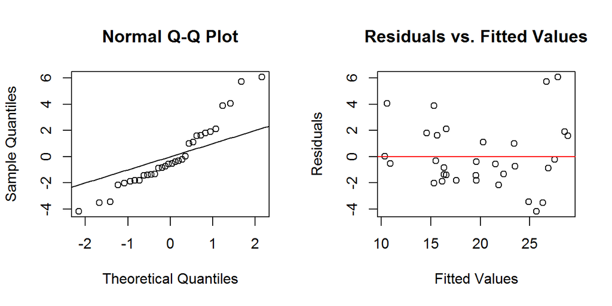

```r
par(mfrow=c(1,2))
qqnorm(Mod$residuals)
x <- seq(-4,4,0.1); y <- x; lines(x=x, y=y)
plot(x = Mod$fitted.values, y = Mod$residuals, xlab = "Fitted Values", ylab = "Residuals",
     main = "Residuals vs. Fitted Values")
lines(x = seq(9,40,0.1), y = rep(0,311), col = "red")
```

## 5.2 Likelihood Ratio Tests

We perform a likelihood ratio test to test the hypothesis if adding additional variables to the simple linear regression model leads to a better model. The resulting p-value is less than 0.05 (the significance level) and therefore we reject the null hypothesis, which is that adding new variables does not lead to a better fit.

```r
lrt <- lrtest(LinMod, Mod); lrt$`Pr(>Chisq)`[2]
```

```
## [1] 5.919406e-10
```

# 6 Conclusion

Based on the values of the adjusted R squared for the simple and the multivariable regression models, the p-values for the regression coefficients and the likelihood ratio test, we can conclude that the multivariable model predicts more accurately the “mpg” for the “mtcars” dataset.